# DA2_Assignment1

Bruno Helmeczy

29/11/2020

## Executive Summary

This report analyses the pattern of association between confirmed Covid-19 cases, and the respective number of Covid-19 related deaths countries experienced, as of 20th October, 2020. After initial visual inspection, 4 log-log linear regression models were estimated and compared, from which the population weighted log-log linear regression model was selected. The model boasts statistically very significant regression parameters and explains 92.9% of variation in Covid-19 related deaths among countries, with variation in confirmed Covid-19 cases (adjusted R-squared). According to this model, people observing 10% larger number of confirmed cases in a country, on average can expect to observe 9.5% larger number of deaths. The core message is two-fold: 1st, the association pattern is close to 1, a value implying constant ratio between case & death figures i.e. virus deadliness. 2nd, the 0.05 deviation in the slope parameter, points to how other factors could also be useful to consider in addition to cases, in order to better predict covid-19 related deaths.

Indeed, Age and Health were shown to influence Covid-19 infected individuals’ probability of dying, therefore including such demographic variables at the national level could improve the chosen models’ predictive power. On the other hand, countries report their deaths differently, some possibly including deaths due to covid-related complications, or only noting deaths due to covid, if no other health-problem was apparent in a subject. Uncovering significant deviations in figures if covid-deaths were interpreted differently, could potentially invalidate the analysis presented below.

#### 1) Introduction:

This report investigates how well can confirmed covid-19 cases explain covid-19 related deaths, i.e. the research question is: “How many deaths can be expected, knowing how many confirmed cases there are in a country?” The researchs’ population are all Covid infected people worldwide, from which Covid-related statistics where sampled in cross-sectional format as of 20th October, 2020, aggregated to country-level. Data Quality issues are apparent in terms of Validity & Reliability: It takes 7 days to for those infected to show symptoms, while the logistics of administering, conducting and reporting tests may take an additional week, unless people omitt to request testing altogether, resulting in unidentified cases.

Indeed, researchers claimed national Covid-19 figures observed at a point in time are rather an estimate of the situation 10-14 days ago. A country’s size may also be a source of bias, due to smaller countries being able to implement reactionary measures faster, to manage virus spread and especially deaths. On the other hand, the difference between true virus related cases and deaths versus currently available figures constitute a larger proportion of true virus related figures, causing a stronger negative bias, if measured in percentages.

#### 2) Filtering & Scaling Observations:

Covid-19 related data was collected from Johns Hopkins University, aggregated to country-level, scaled by 1.000, and merged with national population data scaled by a 1.000.000. Countries whom did not report confirmed number of cases or population figures, were removed (23), together with countries reporting 0 deaths (12) (treated as outliers), netting 170 countries observed.

#### 3) Histograms & Summary Stats:

Histograms of countries Population, Cases, & Deaths resemble a power-law distribution with few positive outliers, i.e. frequencies decreasing by a similar ratio interval-to-interval. Skewness is visible in all cases (ranging 6.6-7.3), variable means being above 75th percentiles.

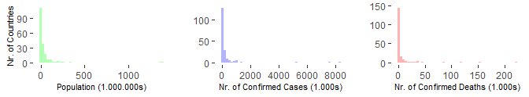

| Variable | Min | 1st IQR | Median | 3rd IQR | Max | Mean | StDev | Skewness |
| --- | --- | --- | --- | --- | --- | --- | --- | --- |
| Covid-19 Cases (1000s) | 0 | 3.73 | 18.75 | 101.14 | 8295.14 | 224.10 | 932.02 | 7.30 |
| Covid-19 Deaths (1000s) | 0 | 0.06 | 0.30 | 1.66 | 221.27 | 6.18 | 23.36 | 6.63 |

#### 4) Ln Transformations:

A theoretical power-law distribution approximates both observed variables well, thus logarithmic transformations created approximately normal distributions for both number of confirmed cases & deaths. Scatter-plots in turn show visibly strong log-log linear association, meaning percentage changes in confirmed cases numbers can be strongly associated with percentage changes in deaths. Substantively, population is power-law distributed, and global-, or national pandemics are declared based on a predetermined percentage of population becoming infected. Meanwhile, viruses deadliness is measured in terms of the percentage of infected people dying, a theoretically constant value, which would imply the percentage change of Covid cases to equal the percentage change of deaths (i.e. a slope parameter of 1 between these log-transformed variables).

#### 5) Model Choice & Interpretation:

The chosen regression model is the Log-Log Weighted Linear Regression, weighed by countries’ populations. Please see the models’ graph and formula below. For an argument on model choice, please visit the appendices.

| Pop. Weighed Log-Log Linear Regression equation: |
| --- |
| ln( Death ) = -3.39 + 0.95 * ln( Confirmed Cases ) |

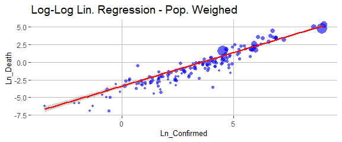

Though the intercept (alpha) parameter is not meaningfully interpretable with a log-log regression model, its slope (beta) parameter tells, that for people across all countries, a +10 percent change in confirmed Covid-19 cases is associated with +9.5 percent change in Covid-19 related deaths, on average. Though all models yielded a slope parameter close to 1, the chosen model weighs the importance of a countries’ statistics by its’ population. While negating the impact of large number of smaller countries with less covid cases and deaths, this model implicitly accepts the notion that how well the pandemic is managed worldwide is a function of total cases worldwide, and some countries contribute to this figure more then others.

#### 6) Beta Parameter Hypothesis Test:

The 1st necessity to establish any meaningful pattern association between the number of confirmed cases and deaths, is testing whether beta, the slope parameter is equal to zero. Thus, the null-hypothesis is Beta = 0, the alternative hypothesis being Beta not being equal to zero. The chosen significance level is 0.1%, due to the realistic need for leaders to be absolutely sure of such an association for decision-making, meaning the maximum accepted probability of a false-positive is 0.001. For the test to satisfy this requirement, the t-statistic must be at least 3.1 distance from 0.

|  | Estimate | Std. Error | t value | Pr(>\|t\|) | CI Lower | CI Upper | DF |
| --- | --- | --- | --- | --- | --- | --- | --- |
| (Intercept) | -3.3906 | 0.3692 | -9.1843 | 0 | -4.1194 | -2.6618 | 168 |
| Ln_Confirmed | 0.9516 | 0.0624 | 15.2531 | 0 | 0.8284 | 1.0748 | 168 |

As visible from the table above, the beta parameters’ (Ln_Confirmed) t value is 15.25, providing ample evidence to reject the null hypothesis, and accept the alternative hypothesis, that the beta parameter is not equal to zero, with 99.9% confidence. In fact, there is less than 1 in a million chance that accepting the alternative hypothesis would result in a false positive error.

#### 7) Residual Analysis:

Best countries were defined as those with largest negative residuals versus respective model-predicted values, while on the flip side, Worst countries as those with largest positive residuals versus model predicted values. If one accepts countries’ deviations from residuals as a measure of job quality nations’ governments have performed in pandemic management thus far, the Singaporean leadership qualifies 1st worldwide, despite being the most densely populated nation, which is supposed to influence its’ pandemic management very negatively.

| Best | Ln_Deaths | Pred | Error | Worst | Ln_Deaths | Pred | Error |
| --- | --- | --- | --- | --- | --- | --- | --- |
| Singapore | -3.58 | 0.47 | -4.05 | Yemen | -0.52 | -2.70 | 2.19 |
| Burundi | -6.91 | -3.96 | -2.95 | Mexico | 4.46 | 3.04 | 1.42 |
| Qatar | -1.50 | 1.24 | -2.74 | Italy | 3.60 | 2.39 | 1.21 |
| Sri Lanka | -4.34 | -1.72 | -2.63 | Ecuador | 2.52 | 1.40 | 1.11 |
| Iceland | -4.51 | -2.03 | -2.48 | United Kingdom | 3.79 | 2.93 | 0.86 |

# Appendices

## 1) Variable Ln-Transformations

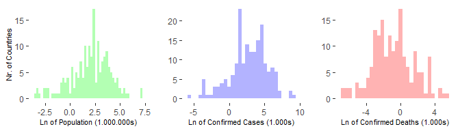

## 2) Variable Scatter-Plots: Level-Level, Level-Log, Log-Level, Log-Log

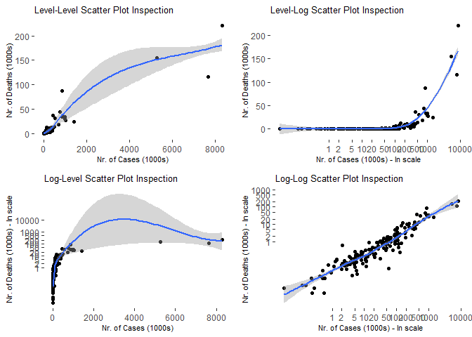

## 3) Model Visuals

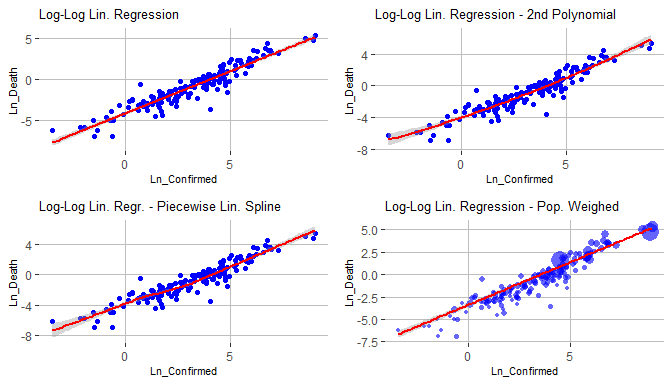

## 4) Model Selection & Statistical Summaries

Based on scatter-plot visuals, both variables of interest were log-transformed, from which 4 regression models were estimated: 1st a Log-Log Linear Regression, 2nd a Log-Log 2nd degree Polynomial regression, 3rd a Log-Log Piecewise Linear Spline Regression, and 4th a Log-Log Weighted linear Regression, weighed by countries’ respective populations. Using log-log models, their interpretations are “a certain percentage change in Confirmed Cases being associated with a certain percentage change in Deaths”. Overall, the 4 models perform well, each explaining at least 89% of variation in percentage change in Deaths, by the percentage change in Confirmed cases, while producing statistically significant parameters. The population weighed log-log regression stands out however, explaining 93% of variation in the outcome variable with variation in the explanatory variable. This model however, produced wider standard errors, causing its’ parameters’ sampling distributions to overlap with model 1, the log-log linear regression, both in case of the intercept and slope parameter. Hypothesis tests therefore, would not be able to reject with 95% confidence the hypothesis that these models are statistically the same.

The 2 models however, differ in their interpretation significantly. The simple log-log regression outputs show how much percentage more deaths can a country expect on average, give how much percentage more confirmed cases it has country to country, as opposed to the population weighted regression outputs showing how much percentage more deaths can people expect on average, given how much percentage more confirmed cases there are.

Substantively, this makes a significant difference due to the data quality issues outline in the introduction. Firstly, the complexity associated with managing the pandemic at a national level is different depending on country size, thus smaller countries’ leaders arguably have an easier job managing infection rates once the virus is identified, as they are faster able to implement directives versus significantly larger countries. Thus it can be expected smaller countries are better able to minimize the number of deaths relative to the number of cases observed, skewing the true association pattern.

Secondly, the percentage difference between measured- and true virus-related figures is greater in smaller countries, and weighing smaller-country observations equally to large ones (e.g. Liechtenstein versus China) exposes the model to measurement errors in smaller countries. For these reasons, despite their parameters’ sampling distributions overlapping, my chosen model is the population weighted log-log regression model.

|  | Ln_Deaths | Ln_Deaths | Ln_Deaths | Ln_Deaths - Weighted |
| --- | --- | --- | --- | --- |
| (Intercept) | -4.10 *** | -4.00 *** | -3.85 *** | -3.39 *** |
|  | (0.12) | (0.13) | (0.15) | (0.37) |
| Ln_Confirmed | 1.03 *** | 0.89 *** |  | 0.95 *** |
|  | (0.03) | (0.06) |  | (0.06) |
| Ln_Confirmed_sq |  | 0.02 ** |  |  |
|  |  | (0.01) |  |  |
| lspline(Ln_Confirmed, cutoff_ln)1 |  |  | 1.03 *** |  |
|  |  |  | (0.17) |  |
| lspline(Ln_Confirmed, cutoff_ln)2 |  |  | 0.78 *** |  |
|  |  |  | (0.11) |  |
| lspline(Ln_Confirmed, cutoff_ln)3 |  |  | 1.19 *** |  |
|  |  |  | (0.05) |  |
| nobs | 170 | 170 | 170 | 170 |
| r.squared | 0.89 | 0.89 | 0.89 | 0.93 |
| adj.r.squared | 0.89 | 0.89 | 0.89 | 0.93 |
| statistic | 1257.39 | 718.98 | 523.14 | 232.66 |
| p.value | 0.00 | 0.00 | 0.00 | 0.00 |
| df.residual | 168.00 | 167.00 | 166.00 | 168.00 |
| nobs.1 | 170.00 | 170.00 | 170.00 | 170.00 |
| se_type | HC2.00 | HC2.00 | HC2.00 | HC2.00 |
| *** p < 0.001; ** p < 0.01; * p < 0.05. |  |  |  |  |